# Results for Wellcome Trust Grant Proposal

2025-01-14

## PSS

To evaluate the relationship between heat exposure and sleep, stress data were paired with daily maximum Wet Bulb Globe Temperature (WBGT) values specific to each participant’s community. The analyses and outputs below focus solely on the pre-natal surveys conducted in the third trimester.

WBGT was selected as the primary temperature metric for this analysis, along with the analyses below, because it is widely recognized as a comprehensive measure of heat stress, capturing the combined effects of temperature, humidity, wind speed, and solar radiation. WBGT is use by military agencies, OSHA, and other organizations as a guide to managing activity level.

### Distributed Lag Model (DLM)

A Distributed Lag Model (DLM) was employed to assess the relationship between daily maximum WBGT and perceived stress scores (PSS-4) over a 270-day lag period prior to survey completion. A cross-basis matrix was constructed to account for both the immediate and lagged effects of temperature, using smooth cubic splines to capture non-linear relationships. Predictions were generated relative to the median temperature (26°C) to evaluate how temperature and lagged exposure impact stress levels.

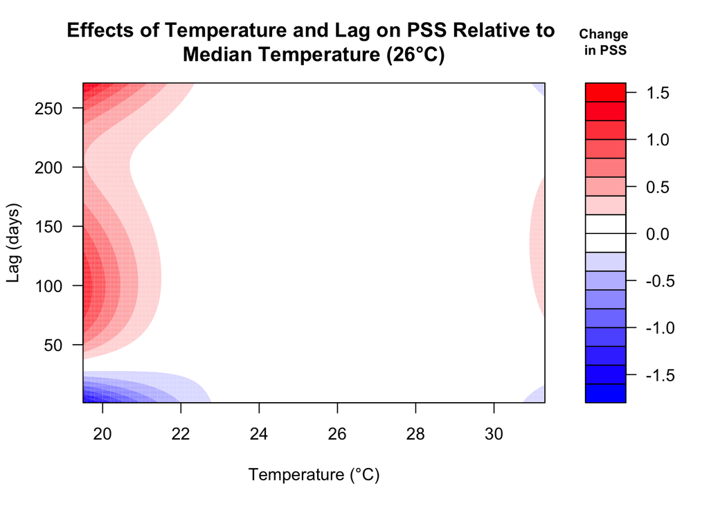

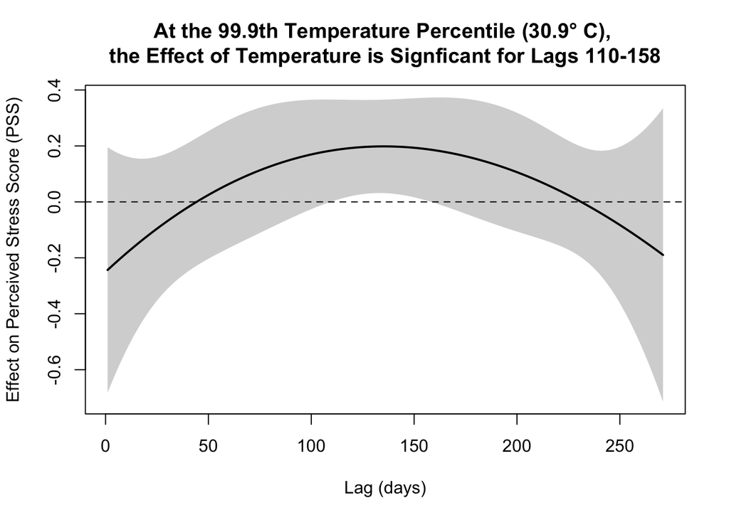

The plots above illustrate the association between temperature and perceived stress scores (PSS) over various lag periods. Compared to the median temperature, temperatures at the upper extremes, such as those above 31°C, are associated with increased stress scores roughly 4-5 months before the survey date. However, at both longer and shorter lag periods (9 months before the survey and the few weeks before the survey), these extremely high temperatures appear to show a slight, non-significant mitigating effect, with stress scores decreasing relative to the median temperature (26°C).

### Unadjusted regression

To further investigate the relationship between WBGT and perceived stress scores (PSS-4) over the pregnancy period, trimester-specific averages and the overall average temperature during pregnancy were computed. For the third trimester and entire pregnancy, average WBGT values were calculated only up to the date of the survey to ensure alignment with the stress assessment period. Linear regression models were then used to evaluate the association between PSS-4 and WBGT averages for each time period.

```
##
## Regression Results: PSS vs. WBGT Temperatures
## ================================================================================================================
##                                                               Dependent variable:
##                                 --------------------------------------------------------------------------------
##                                                              Perceived Stress Score
##                                 Entire Pregnancy Pre-Conception First Trimester Second Trimester Third Trimester
##                                       (1)             (2)             (3)             (4)              (5)
## ----------------------------------------------------------------------------------------------------------------
## `Average Temp Entire Pregnancy`      0.87**
##                                      (0.28)
## `Average Temp Pre-Conception`                        -0.13
##                                                      (0.15)
## `Average Temp First Trimester`                                      0.47**
##                                                                     (0.15)
## `Average Temp Second Trimester`                                                     0.59***
##                                                                                      (0.17)
## `Average Temp Third Trimester`                                                                        -0.02
##                                                                                                      (0.21)
## Constant                            -17.20*          10.15*          -6.48           -9.43*           6.90
##                                      (7.50)          (3.99)         (4.11)           (4.52)          (5.59)
## ----------------------------------------------------------------------------------------------------------------
## Observations                          428             428             428             428              428
## R2                                    0.02           0.002           0.02             0.03           0.0000
## Adjusted R2                           0.02          -0.0004          0.02             0.03           -0.002
## ================================================================================================================
## Note:                                                                              *p<0.05; **p<0.01; ***p<0.001
```

The regression analysis explores the association between wet bulb globe temperature (WBGT) and perceived stress scores (PSS-4) during different periods of pregnancy. The results indicate that:

- **Entire Pregnancy**: Higher average daily maximum WBGT during the entire pregnancy is significantly associated with an increase in PSS-4 scores (β = 0.87, p < 0.01) at the time of the third trimester survey, suggesting that overall heat exposure may elevate perceived stress levels. For every one degree increase in the average daily maximum WBGT, our model predicts that the perceived stress score would increase on average by 0.87
- **Trimester-Specific Averages**: Higher average daily maximum WBGT during the first (β = 0.47, p < 0.01) and second trimesters (β = 0.59, p < 0.001) are associated with a significant increase in PSS-4 scores. The third trimester average showed no such effect, indicating that the temperatures nearest to the survey date appear less strongly associated with stress scores.
- **Pre-Conception**: Higher WBGT during the pre-conception period is associated with a slight, insignificant reduction in PSS-4 scores, mirroring the distributed lag model results.

## Sum NDS Category

The Sum NDS Category was determined using data from the Life Events Questionnaire, which assessed participants’ experiences with significant events over the prior six months. Participants were asked if events occurred, and if so, whether they were positive, negative, or neutral. Events were categorized into 12 domains, including financial, legal, medical and others. A negative domain score (NDS) was calculated by summing all of the domains for which a participant experienced at least one negatively perceived event. These scores were then classified into three groups: low stress (NDS = 0-2), moderate stress (NDS = 3-5), and high stress (NDS > 5).

The dataset includes responses from 353 participants distributed across three survey periods: the far postnatal period (n = 113), the postpartum period (n = 230), and the third trimester (n = 10). The postpartum period refers to surveys conducted within six weeks after delivery, while far postnatal refers to surveys conducted after that.

### Distributed Lag Model

A Distributed Lag Model (DLM) was employed to assess the relationship between daily maximum WBGT and Sum NDS Category over a 270-day lag period prior to survey completion. A cross-basis matrix was constructed to account for both the immediate and lagged effects of temperature, using smooth cubic splines to capture non-linear relationships. Predictions were generated relative to the median temperature (27.4°C) to evaluate how temperature and lagged exposure impact resilience.

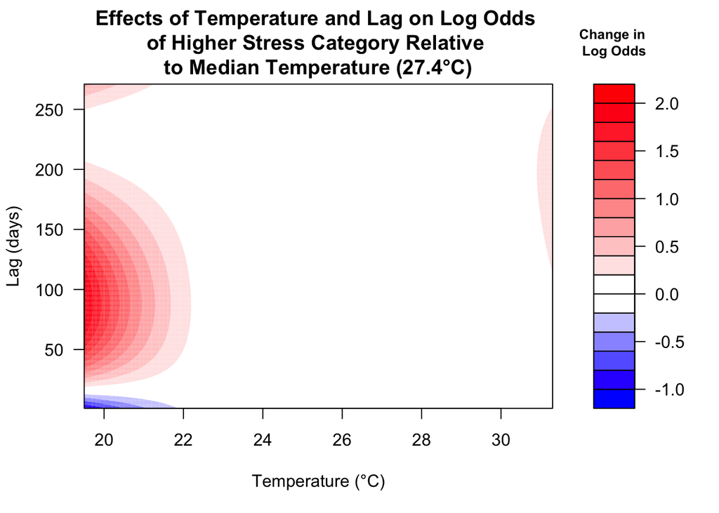

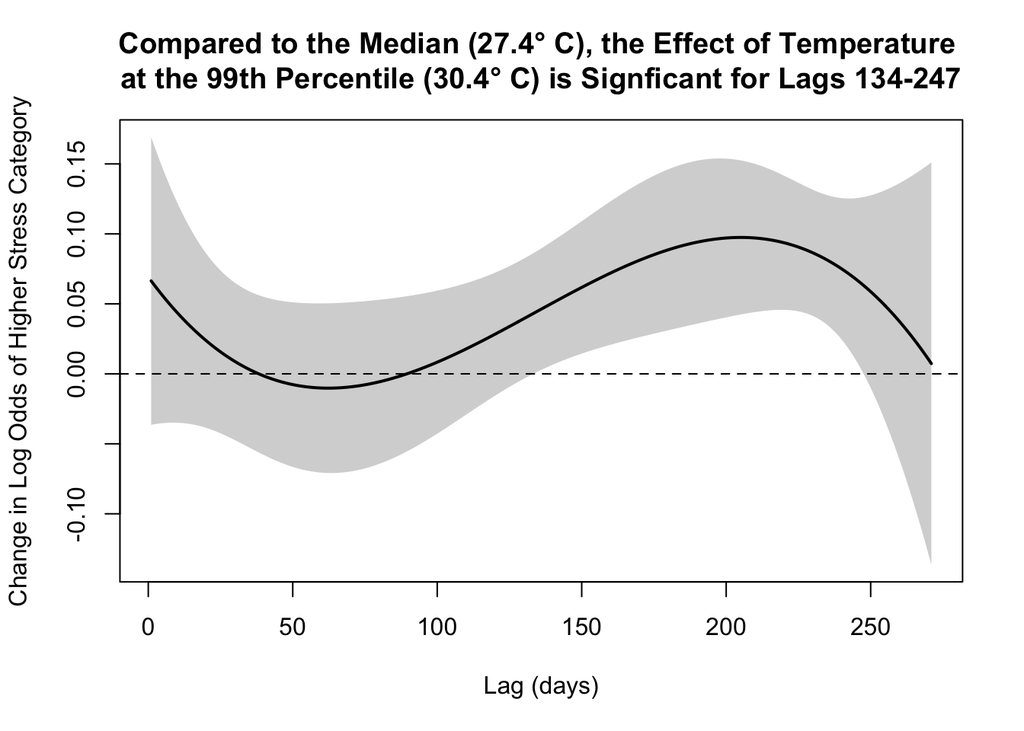

The plots above illustrate the association between temperature and stress score (through Sum NDS Category) over various lag periods. Compared to the median temperature 27.4°C, temperatures at the upper extremes, such as those above 30°C, are associated with increased stress scores roughly 5-8 months before the survey date.

### Unadjusted regression

To further investigate the relationship between daily maximum WBGT and Sum NDS Category score over the pregnancy period, trimester-specific averages and the overall average temperature during pregnancy were computed. For the third trimester and entire pregnancy, average WBGT values were calculated only up to the date of the survey to ensure alignment with the stress assessment period. Linear regression models were then used to evaluate the association between Sum NDS Category and WBGT averages for each time period.

Ordered Logistic Regression Results

Higher WBGT during pre-conception, the first trimester, and the entire pregnancy period as a whole associated with increased likelihood of belonging to a higher stress group.

| Model | Coefficient | Std. Error | Odds Ratio | P-Value |
| --- | --- | --- | --- | --- |
| Pre-Conception | 0.176 | 0.085 | 1.193 | 0.038 |
| First Trimester | 0.301 | 0.096 | 1.351 | 0.002 |
| Second Trimester | 0.165 | 0.092 | 1.179 | 0.072 |
| Third Trimester | −0.003 | 0.086 | 0.997 | 0.976 |
| Entire Pregnancy | 0.443 | 0.153 | 1.557 | 0.004 |

The regression analysis explores the association between wet bulb globe temperature (WBGT) and stress using the Sum NDS Category during different periods of pregnancy. The results indicate that:

- **Entire Pregnancy**: Higher average daily maximum WBGT during the entire pregnancy is significantly associated with belonging to a higher stress group, with a one degree increase in WBGT associated with a 55.7% increase in the odds of belonging to a higher stress group (p = 0.004).
- **Pre-Conception**: Higher average daily maximum WBGT during the pre-conception period is significantly associated with belonging to a higher stress group, with a one degree increase in WBGT associated with a 19.3% increase in the odds of belonging to a higher stress group (p = 0.038).
- **Trimester-Specific Averages**: Higher average daily maximum WBGT during the first trimester is significantly associated with belonging to a higher stress group, with a one degree increase in WBGT associated with a 35.1% increase in the odds of belonging to a higher stress group (p = 0.002). While the second trimester showed a positive association between temperature and Sum NDS Category, the effect was not significant. The third trimester average showed no effect, indicating that the temperatures nearest to the survey date appear less strongly associated with the Sum NDS Category.

## Actigraphy

Actigraphy data were collected from 156 participants, with some contributing data from multiple studies conducted at two follow-up periods: 4 and 8 years after birth. These studies included single-night (n = 48) and multinight (n = 52) recordings at year 4, as well as single-night (n = 4) and multinight (n = 80) recordings at year 8. For this analysis, data were combined from the four actigraphy studies.

To evaluate the relationship between heat exposure and sleep, actigraphy data were paired with daily maximum WBGT values specific to each participant’s community. The mean WBGT was calculated for each participant over their actigraphy study period. One temperature outlier (18.7°C) was excluded due to its high leverage on the model. Additionally, six participants without matching community climate data were removed, resulting in a final dataset of 149 unique participants.

A linear regression model was employed to examine the association between average WBGT and total sleep time (TST), providing insights into the impact of heat on sleep quantity.

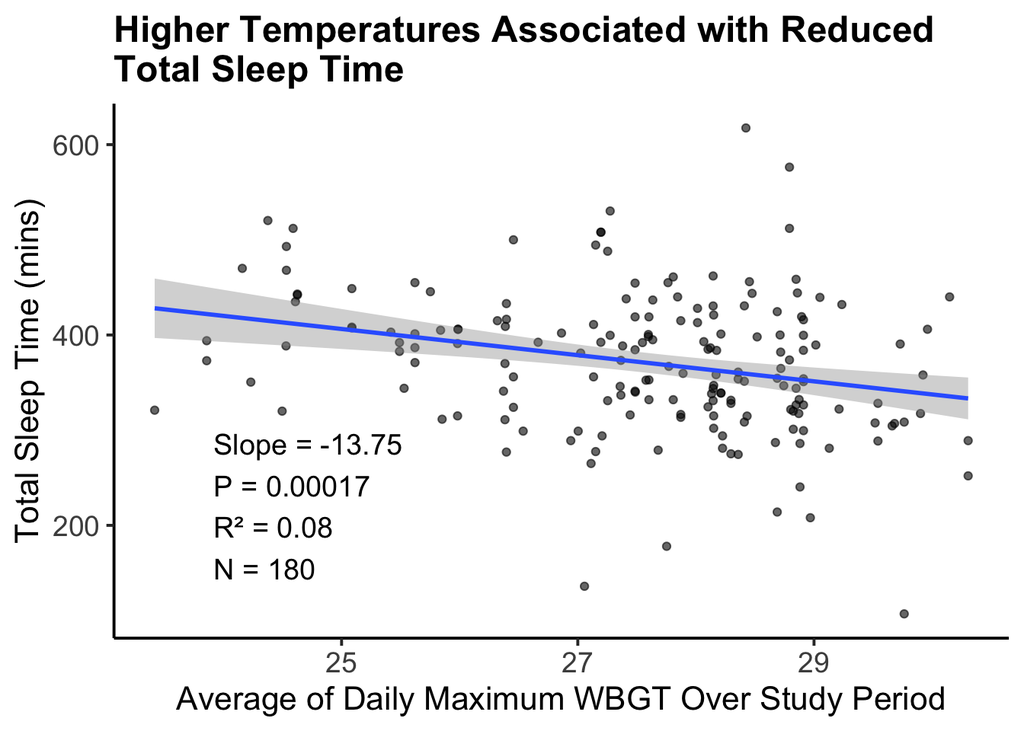

A highly significant negative association is observed, with a slope of -13.75 (p < 0.001), indicating that for each degree increase in the average maximum WBGT, our model predicts that total sleep time decreases by approximately 14 minutes. These findings suggest that higher temperatures during the study period are associated with reduced total sleep duration, which may reflect the challenges of maintaining optimal sleep in warmer conditions.